# Peer Assessment 1

### Loading and preprocessing the data

```r
data<-read.csv("activity.csv")
data$date <-as.Date(data$date,"%Y-%m-%d")
```

### What is mean total number of steps taken per day?

- Calculate the total number of steps taken per day

```r
library(dplyr)
steps_per_day <-filter(data,!is.na(steps)) %>%group_by(date) %>% summarise(TotalSteps=sum(steps))
```

- Histogram of the total number of steps taken each day

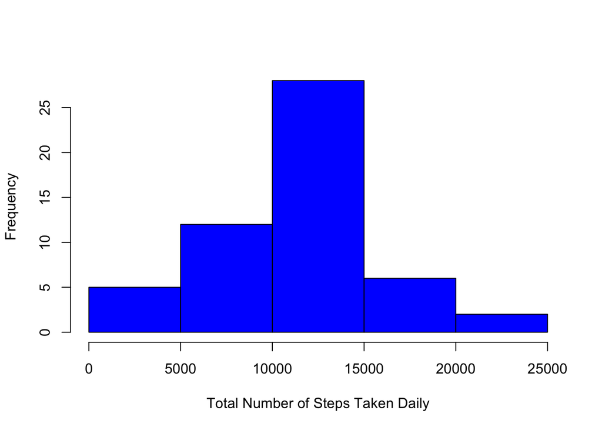

```r
hist(steps_per_day$TotalSteps,main=" ",xlab="Total Number of Steps Taken Daily",col="Blue")
```

- Mean of total number of steps taken each day

```r
mean(steps_per_day$TotalSteps);
```

```
## [1] 10766.19
```

- Median total number of steps taken each day

```r
median(steps_per_day$TotalSteps);
```

```
## [1] 10765
```

### What is the average daily activity pattern?

- A time series plotof the 5-minute interval and the average number of steps taken, averaged across all days

```r
avg_steps<-filter(data,!is.na(steps)) %>%group_by(interval) %>% summarise(AvgSteps=mean(steps))
```

- The plot

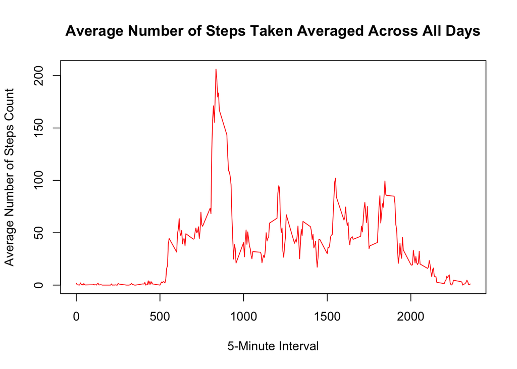

```r
plot(avg_steps$AvgSteps~avg_steps$interval,type='l',xlab="5-Minute Interval",ylab="Average Number of Steps Count",main="Average Number of Steps Taken Averaged Across All Days",col="red")
```

- Which 5-minute interval, on average across all the days in the dataset, contains the maximum number of steps?

```r
avg_steps[which.max(avg_steps$AvgSteps), ]
```

```
## Source: local data frame [1 x 2]
##
##   interval AvgSteps
## 1      835 206.1698
```

### Imputing missing values

- Calculate and report the total number of missing values in the dataset

```r
data_NA <- sum(is.na(data))
data_NA
```

```
## [1] 2304
```

- Devise a strategy for filling in all of the missing values in the dataset. I will use the mean for that 5-minute interval.

```r
data <- merge(data,avg_steps, by = "interval")
nas <- is.na(data$steps)
data$steps[nas] <- data$AvgSteps[nas]
data_filled <- data[, c(1:3)]
```

- Calculate the total number of steps taken per day after Imputating NAs.

```r
steps_per_day_filled <-data_filled %>%group_by(date) %>% summarise(TotalSteps=sum(steps))
```

- A histogram of the total number of steps taken each day after Imputating NAs.

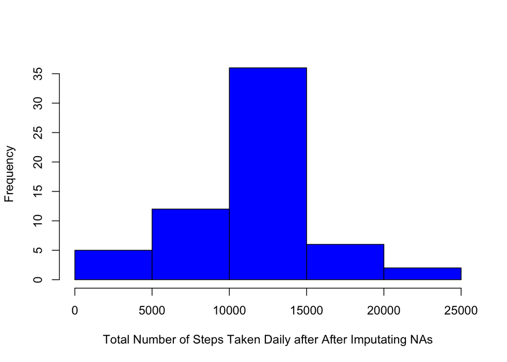

```r
hist(steps_per_day_filled$TotalSteps,main=" ",xlab="Total Number of Steps Taken Daily after After Imputating NAs",col="Blue")
```

- Mean of total number of steps taken each day for new data set

```r
mean(steps_per_day_filled$TotalSteps);
```

```
## [1] 10766.19
```

- Median total number of steps taken each day for new data set

```r
median(steps_per_day_filled$TotalSteps);
```

```
## [1] 10766.19
```

### Are there differences in activity patterns between weekdays and weekends?

- Create a new factor variable in the dataset with two levels – “weekday” and “weekend” indicating whether a given date is a weekday or weekend day.

```r
data_filled$weektime <- as.factor(ifelse(weekdays(data_filled$date) %in% c("Saturday","Sunday"),"weekend", "weekday"))
```

- A panel plot containing a time series plot of the 5-minute interval and the average number of steps taken, averaged across all weekday days or weekend days.

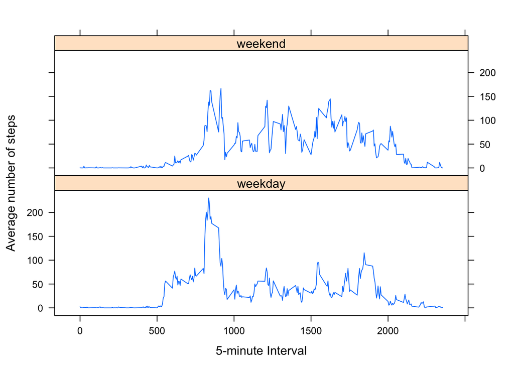

```r
library("lattice")
avg_steps_new<-data_filled %>%group_by(interval,weektime) %>% summarise(AvgSteps=mean(steps))
xyplot(AvgSteps ~ interval | weektime, avg_steps_new, type = "l", layout = c(1, 2), xlab = "5-minute Interval", ylab = "Average number of steps")
```